# Data Visualization in R with ggplot2 Workshop

Solutions to the provided exercises

JHU Data Services

2022-10-12

## Your Turn 0 - Using RMarkdown

You can embed an R code chunk like this:

```r
## My code
```

Modify the setup chunk to import the **tidyverse** library:

```r
library(tidyverse)
```

```r
## Configures the size of plots displayed in the knitted document
knitr::opts_chunk$set(echo = TRUE, fig.width = 5, fig.height = 3)
```

## Your Turn 1 - Explore the data

Using `head`, `glimpse`, or `skim`, answer: - How many **variables** are present? 14 (from glimpse) - How many **observations** are present? 87 (from glimpse) - How many **numeric** variables are present? What are they? 3, height, mass, birth_year (from skim)

```r
# head will provide solutions to all except observations
head(starwars)

# glimpse (from dplyr) or skim (from skimr) will provide answers to all solutions.
glimpse(starwars)

# To load skimr:
library(skimr)
skim(starwars)

# To see numeric columns, with names, specifically, you can use `select_if()` from dplyr:
select_if(starwars, is.numeric)
```

### Solution

- 14 variables are present. The number of variables correspond to the number of columns in our `starwars` dataframe.
- 87 observations present. The number of observations correspond to the number of columns in the `starwars` dataframe.
- There are 3 numeric variables. They are height, mass, birth_year.

## Your Turn 2 - Mappings

1. Modify the code below to plot height vs. birth_year. See `?starwars` for the definition of `birth_year` in this context.

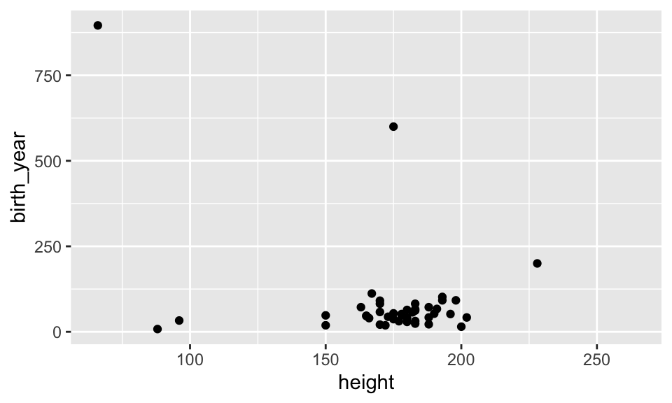

   ```r
   ggplot(data = starwars, mapping = aes(x = height,
                                         y = birth_year)) +
     geom_point()
   ```

2. You should observe that a few observations appear to be outliers. Can you guess who those characters are? Hint: Run `View(starwars)` in the Console to take a look at the raw data.

### Solution

Their are three outliers (three points appear visually distanct in birth year from the remainder of points). We can confirm that these three points are in fact outliers using a boxplot:

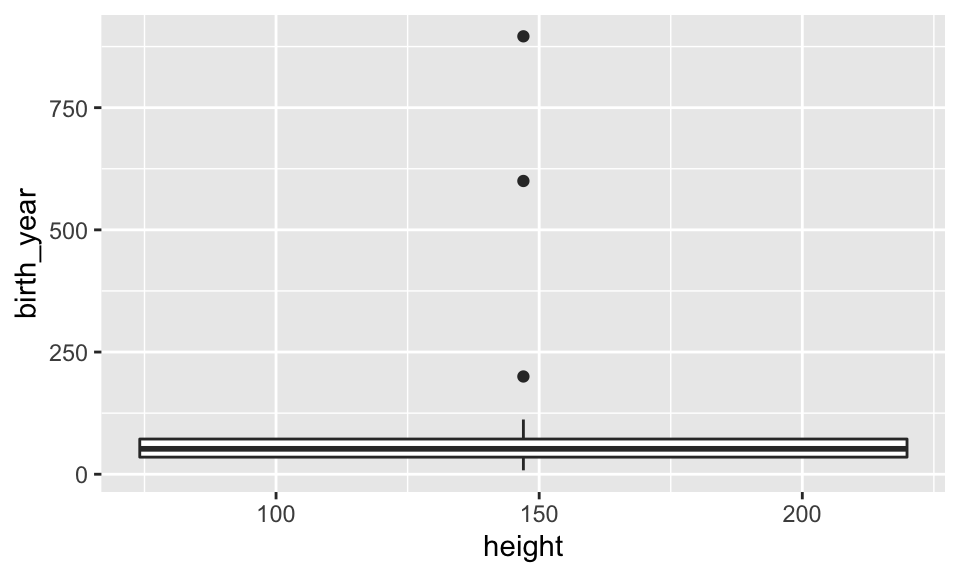

```r
ggplot(data = starwars, mapping = aes(x = height,
                                      y = birth_year)) +
  geom_boxplot()
```

We can use an arrange (from `dplyr`) to sort in descending order by birth_year and return the first three occurrences:

```r
starwars %>% arrange(-birth_year) %>% slice(1:3)
```

```
## # A tibble: 3 × 14
##   name         height  mass hair_…¹ skin_…² eye_c…³ birth…⁴ sex   gender homew…⁵
##   <chr>         <int> <dbl> <chr>   <chr>   <chr>     <dbl> <chr> <chr>  <chr>
## 1 Yoda             66    17 white   green   brown       896 male  mascu… <NA>
## 2 Jabba Desil…    175  1358 <NA>    green-… orange      600 herm… mascu… Nal Hu…
## 3 Chewbacca       228   112 brown   unknown blue        200 male  mascu… Kashyy…
## # … with 4 more variables: species <chr>, films <list>, vehicles <list>,
## #   starships <list>, and abbreviated variable names ¹hair_color, ²skin_color,
## #   ³eye_color, ⁴birth_year, ⁵homeworld
```

## Your Turn 3 - Aesthetics

1. Map the variable `sex` to both point color and shape. What do you notice?

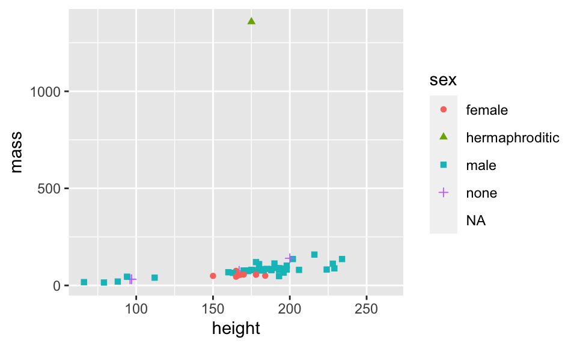

   ```r
   ggplot(data = starwars,
          mapping = aes(x = height,
                        y = mass,
                        color = sex,
                        shape = sex)) +
     geom_point()
   ```

### Solution

NA is not plotted. This is a feature of `ggplot2`. To fix use replace_na from `tidyr`:

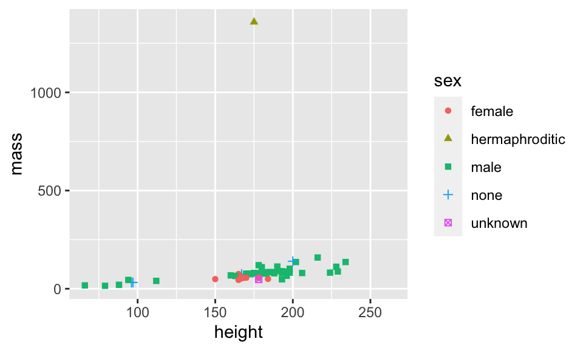

```r
starwars = starwars %>%
  mutate(sex = replace_na(sex, "unknown"))
ggplot(data = starwars,
       mapping = aes(x = height,
                     y = mass,
                     color = sex,
                     shape = sex)) +
  geom_point()
```

Now the NAs, renamed to “unknown”, are shown.

2. Try mapping a categorical variable to x, for example `eye_color`. What happens?

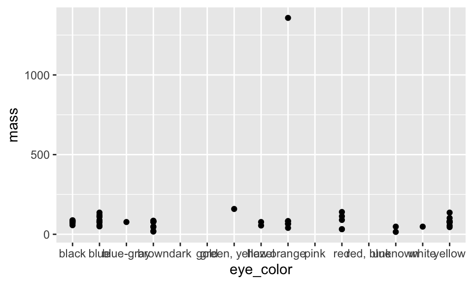

   ```r
   ggplot(data = starwars,
          mapping = aes(x = eye_color,
                        y = mass)) +
     geom_point()
   ```

A scatterplot (`geom_point()`) is being used to repesent categorical data. A scatter plot should not be used to compare a categorical to a continuous variable. Instead a boxplot (`geom_boxplot()`), violin plot (`geom_violin()`), jitter plot (`geom_jitter()`), or beeswarm plot (`geom_beeswarm()` from the **ggbeeswarm** package) would be more appropriate.

3. Try mapping a continuous variable to shape, for example `mass`. What happens?

   ```r
   ggplot(data = starwars,
          mapping = aes(x = height,
                        y = mass,
                        shape = mass)) +
     geom_point()
   ```

### Solution

A continuous variable can not be mapped to a categorical aesthetic like shape, and you will receive an error indicating as much.

## Your Turn 4 - Themes

1. Modify the following plot to use a `theme_minimal()` theme.

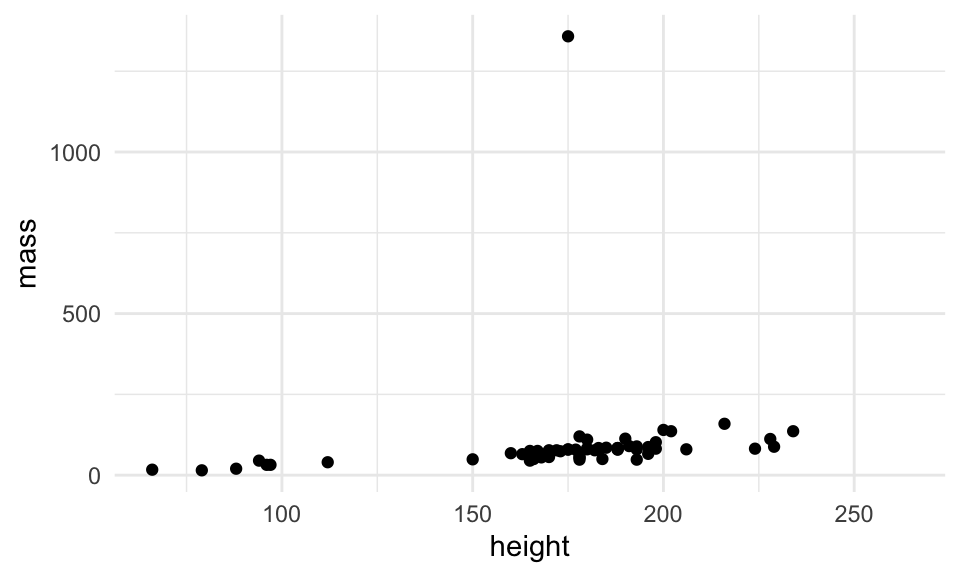

```r
ggplot(data = starwars,
       mapping = aes(x = height,
                     y = mass)) +
  geom_point() +
  theme_minimal()
```

2. Modify the below plot to:
- Add a plot title “Mass vs. height of Starwars characters”
- Add the plot subtitle “by gender and birth year”
- Add the x-label “Height (cm)”
- Add the y-label “Weight (kg)”
- Set the axis tick labels to size 14
- Set the axis titles to size 16
- Set the plot tile to size 18

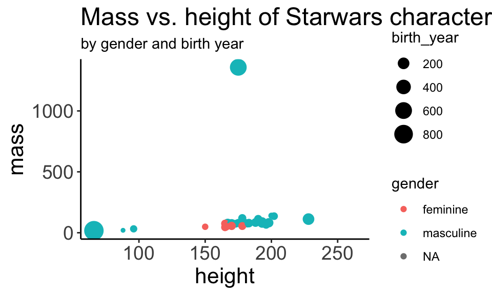

```r
ggplot(data = starwars,
       mapping = aes(x = height,
                     y = mass,
                     color = gender,
                     size = birth_year)) +
  geom_point() +
  labs(title = "Mass vs. height of Starwars characters",
       subtitle = "by gender and birth year") +
  theme_classic() +
  theme(axis.text = element_text(size = 14),
        axis.title = element_text(size = 16),
        plot.title = element_text(size = 18),
        legend.position = )
```